# Tutorial 5: Trajectory Selection

## 8. Effect of tolerance ε

The tolerance `ε` is the key tuning parameter. Here we sweep over several values to show the trade-off between **specificity** (small ε → selected trajectories are close to the observed data) and **coverage** (large ε → selected trajectories span the full NROY ensemble).

A useful diagnostic is the **effective sample size** $N_{\mathrm{eff}} = \left(\sum_i w_i^2\right)^{-1}$. When $N_{\mathrm{eff}} \ll N$ the weight distribution is too concentrated; when $N_{\mathrm{eff}} \approx N$ the selection is almost uniform (lenient).

```python
epsilons = [obs_peak * f for f in [0.02, 0.05, 0.10, 0.20, 0.40]]

fig, axs = plt.subplots(1, len(epsilons), figsize=(16, 4), sharey=True)

for ax, eps in zip(axs, epsilons):
    w   = gaussian_weights(inc_matrix, obs_array, epsilon=eps)
    nef = 1 / (w**2).sum()

    idx_sel = rng.choice(len(ensemble_df), size=N_SELECT, replace=False, p=w)
    sel_inc = inc_matrix[idx_sel]

    ax.fill_between(
        range(N_DAYS),
        np.percentile(sel_inc, 10, axis=0),
        np.percentile(sel_inc, 90, axis=0),
        alpha=0.3, color='purple', label='10–90 pct',
    )
    ax.plot(sel_inc.mean(axis=0), color='purple', lw=2)
    ax.plot(obs_array, 'ko-', ms=3, lw=1.5, zorder=5)
    ax.set_title(f'ε = {eps:.1f}\nNeff = {nef:.0f}')
    ax.set_xlabel('Day')
    ax.grid(ls=':')

axs[0].set_ylabel('Daily new cases')
fig.suptitle('Trajectory selection sensitivity to tolerance ε', fontsize=12)
fig.tight_layout()
```

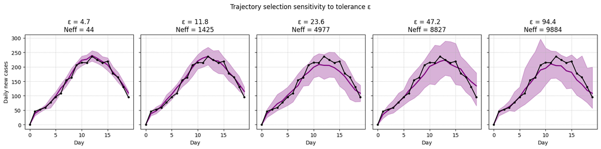

## Summary

[output not shown]

### Key design choices

**Why use summary statistics for HM but full time series for trajectory selection?**  
History matching with the full time series would require one emulator per day — high-dimensional and expensive. Summary statistics keep HM tractable. The trajectory selection step then acts as a second, finer filter using the full data.

**How to choose ε?**  
Start with ε ≈ 10% of the observed peak. Check the effective sample size — aim for $N_{\mathrm{eff}} \gtrsim 50$. If the selected trajectories look too broad, tighten ε. If they look implausibly narrow, relax it.

**Using the selected trajectories**  
Each selected `(β, γ, seed)` triple is a complete, reproducible simulation run. You can re-run these with the full model (e.g., longer time horizon, additional compartments) to generate matched forecasts or counterfactuals.